# Does the ADC Improve PFS and OS? A Multi-Lesion RECIST Comparison

Pharmacometrics-inspired modeling in oncology (part 4)

Juliette Bouli-Mengue

## 1. Motivation

Notebook 3 introduced multi-lesion RECIST progression and PFS as a composite endpoint, using the biexponential growth/regrowth model from notebook 1 (no drug mechanism). Notebook 2 introduced an explicit ADC pharmacokinetic/pharmacodynamic mechanism, but worked with a single aggregate tumor size and a simplified landmark survival analysis.

This notebook combines both: individual lesions (as in notebook 3) are driven by the ADC PK/PD mechanism (as in notebook 2), allowing us to compare PFS and OS between a treated (ADC) arm and an untreated counterfactual arm, using the same RECIST-based progression detection built in notebook 3.

**Two compatibility choices, made explicitly:**

- **Time scale**: this notebook works in **days** (as in notebook 2), extended to 728 days (~104 weeks) to allow enough follow-up time for progression and death events, as in notebook 3.
- **Growth model**: lesions here follow a growth-minus-drug-effect structure (`dSLD/dt = d*SLD - Effect(t)*SLD`). The `d` parameter from notebook 1 represents intrinsic regrowth and is therefore used as the untreated growth rate. The `g` parameter represented treatment-driven regression in notebook 1 and is not reused as natural growth here.

```r
library(dplyr)
library(ggplot2)
library(survival)
library(survminer)

project_root <- Sys.getenv("TUMOR_PROJECT_ROOT", unset = "..")
source(file.path(project_root, "R", "config.R"))
source(file.path(project_root, "R", "pk_pd.R"))
source(file.path(project_root, "R", "recist.R"))
set_project_seed()
```

**Setup check.** PK/PD and RECIST logic are imported from the project modules used by the earlier notebooks. This final notebook combines those validated components rather than redefining them locally.

## 2. Loading the simulated population

We reuse the simulated oncology population generated in notebook 1: each patient has individual tumor growth parameters (`g`, `d`) representing their overall disease trajectory. These patient-level parameters will serve as the basis for simulating several individual lesions per patient in Section 3.

```r
# Assumes patients_final.rds is saved in the same folder as this notebook
# (produced by notebook 1), a relative path, so the project stays portable across machines.
patients <- readRDS("patients_final.rds")

head(patients)
```

```
## # A tibble: 6 × 11
##   patient_id      g       d  SLD0      g_c       d_c linear_pred  hazard
##        <int>  <dbl>   <dbl> <dbl>    <dbl>     <dbl>       <dbl>   <dbl>
## 1          1 0.0397 0.00301  89.6  0.0175  -0.00885      -0.440  0.00966
## 2          2 0.0151 0.0122   46.2 -0.00707  0.000358      0.113  0.0168
## 3          3 0.0240 0.0202   61.0  0.00184  0.00833       0.139  0.0172
## 4          4 0.0274 0.0344   60.9  0.00530  0.0225        0.372  0.0217
## 5          5 0.0245 0.00438  50.4  0.00233 -0.00748      -0.185  0.0125
## 6          6 0.0190 0.00501  44.5 -0.00318 -0.00685      -0.0892 0.0137
## # ℹ 3 more variables: true_event_time <dbl>, os_time <dbl>, os_event <int>
```

**Input check.** The common population is loaded unchanged, preserving patient-level heterogeneity and keeping the treated/no-treatment comparison paired at the level of the underlying disease parameters.

## 3. Simulating multiple lesions per patient

As in notebook 3, each patient has 5 to 10 individual lesions. Each lesion carries an intrinsic regrowth parameter (`d_lesion`) inherited from the patient-level `d`, with lesion-specific variability. This prevents relapse from being attributed solely to loss of drug exposure.

```r
n_lesions_min <- 5
n_lesions_max <- 10

lesions <- patients %>%
  rowwise() %>%
  do({
    pt <- .
    n_lesions <- sample(n_lesions_min:n_lesions_max, 1)

    tibble(
      patient_id = pt$patient_id,
      lesion_id = 1:n_lesions,
      d_lesion = pt$d * runif(n_lesions, 0.7, 1.3),
      SLD0_lesion = (pt$SLD0 / n_lesions) * runif(n_lesions, 0.7, 1.3)
    )
  }) %>%
  ungroup()

head(lesions, 10)
```

```
## # A tibble: 10 × 4
##    patient_id lesion_id d_lesion SLD0_lesion
##         <int>     <int>    <dbl>       <dbl>
##  1          1         1  0.00380       20.5
##  2          1         2  0.00262       14.0
##  3          1         3  0.00361       19.6
##  4          1         4  0.00327       20.1
##  5          1         5  0.00304       17.5
##  6          2         1  0.0119         7.47
##  7          2         2  0.0154         7.33
##  8          2         3  0.0157         4.33
##  9          2         4  0.00941        5.83
## 10          2         5  0.0120         5.40
```

**Observation.** The lesion table provides the common starting state for both arms. Only the treatment mechanism will differ; lesion count, baseline burden, and intrinsic growth are shared within patient.

## 4. Applying PK/PD: repeated dosing, one drug exposure profile per patient

Real ADC regimens involve repeated administration (typically every 21 days), not a single dose. We model plasma concentration using the superposition principle: total concentration at any time is the sum of contributions from all doses already administered, each decaying independently from its own injection time. This produces the characteristic sawtooth accumulation pattern of repeated dosing. For internal consistency, `EC50 = 1` and the population elimination rate are retained from notebook 2. `Emax = 0.003` is deliberately lower than notebook 2’s single-dose value of `0.05`: repeated q3w administration sustains exposure, so copying the single-dose `Emax` produces near-complete, unrealistic progression suppression. This is an empirical scenario calibration, not a clinically estimated ADC parameter.

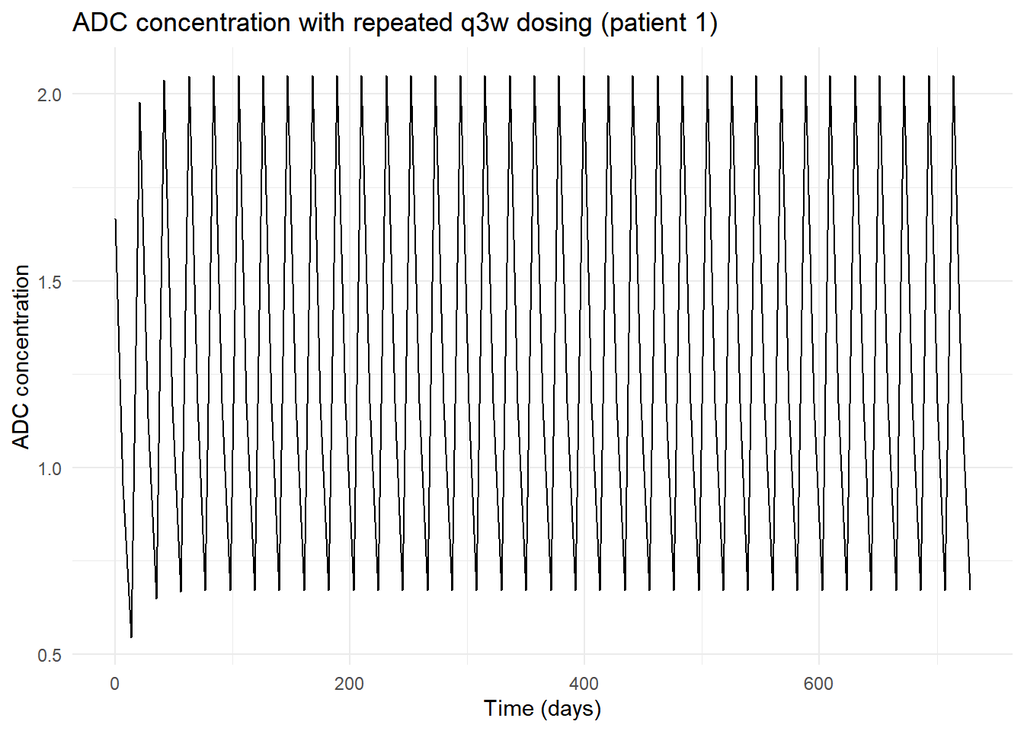

```r
lesions <- lesions %>%
  mutate(d_daily = d_lesion / 7)

dose <- 5     # mg/kg
V    <- 3     # L/kg
EC50 <- 1
Emax <- 0.003  # lower than notebook 2 because exposure is sustained by repeated dosing

patients <- patients %>%
  mutate(kel_i = rlnorm(n(), meanlog = log(0.05), sdlog = 0.20))

time_grid <- seq(0, 728, by = 7)  # days, weekly scans over ~104 weeks
dosing_interval <- 21  # days, typical q3w ADC regimen
dosing_times <- seq(0, 728, by = dosing_interval)

patient_pkpd <- patients %>%
  rowwise() %>%
  do({
    pt <- .
    conc <- repeated_dose_concentration(time_grid, pt$kel_i, dosing_times, dose, V)
    inhibition <- emax_effect(conc, Emax, EC50)
    tibble(patient_id = pt$patient_id, time = time_grid, concentration = conc, inhibition = inhibition)
  }) %>%
  ungroup()

ggplot(patient_pkpd %>% filter(patient_id == 1), aes(x = time, y = concentration)) +
  geom_line() +
  labs(title = "ADC concentration with repeated q3w dosing (patient 1)",
       x = "Time (days)", y = "ADC concentration") +
  theme_minimal()
```

```r
head(patients %>% select(patient_id, kel_i))
```

```
## # A tibble: 6 × 2
##   patient_id  kel_i
##        <int>  <dbl>
## 1          1 0.0798
## 2          2 0.0411
## 3          3 0.0434
## 4          4 0.0569
## 5          5 0.0694
## 6          6 0.0639
```

**PK/PD observation.** Superposition produces the expected q3w sawtooth exposure while patient-specific elimination rates preserve PK heterogeneity. Computing exposure once per patient guarantees that all lesions belonging to that patient receive the same systemic concentration profile. ## 5. Simulating each lesion under repeated-dosing treatment and the no-drug counterfactual

Each lesion now uses its patient’s repeated-dosing inhibition profile (Section 4, computed once per patient) rather than a single-dose profile computed per lesion. As before, we simulate two trajectories per lesion: one under ADC treatment, and one no-drug counterfactual.

```r
lesion_trajectories <- data.frame()

for (i in 1:nrow(lesions)) {
  pid    <- lesions$patient_id[i]
  d_i    <- lesions$d_daily[i]
  SLD0_i <- lesions$SLD0_lesion[i]

  inhibition <- patient_pkpd$inhibition[patient_pkpd$patient_id == pid]

  SLD_adc     <- numeric(length(time_grid)); SLD_adc[1] <- SLD0_i
  SLD_no_drug <- numeric(length(time_grid)); SLD_no_drug[1] <- SLD0_i

  for (t in 2:length(time_grid)) {
    dt <- time_grid[t] - time_grid[t - 1]
    SLD_adc[t] <- SLD_adc[t - 1] + dt *
      (d_i * SLD_adc[t - 1] - inhibition[t - 1] * SLD_adc[t - 1])
    SLD_no_drug[t] <- SLD_no_drug[t - 1] + dt *
      (d_i * SLD_no_drug[t - 1])

    # Euler's method can become non-physical under extreme parameter combinations.
    if (!is.finite(SLD_adc[t]) || SLD_adc[t] < 0) {
      stop("Invalid ADC tumor size; reduce the integration step", call. = FALSE)
    }
  }

  lesion_trajectories <- bind_rows(
    lesion_trajectories,
    data.frame(patient_id = pid, lesion_id = lesions$lesion_id[i], time = time_grid,
               SLD_adc = SLD_adc, SLD_no_drug = SLD_no_drug)
  )
}

head(lesion_trajectories, 10)
```

```
##    patient_id lesion_id time  SLD_adc SLD_no_drug
## 1           1         1    0 20.45281    20.45281
## 2           1         1    7 20.26208    20.53053
## 3           1         1   14 20.13138    20.60854
## 4           1         1   21 20.05864    20.68684
## 5           1         1   28 19.85504    20.76545
## 6           1         1   35 19.70908    20.84435
## 7           1         1   42 19.62126    20.92355
## 8           1         1   49 19.41943    21.00305
## 9           1         1   56 19.27373    21.08286
## 10          1         1   63 19.18503    21.16297
```

**Result.** Each lesion has two aligned trajectories on the same time grid: repeated-dose ADC and no-drug growth. This paired construction is retained through aggregation, RECIST assessment, and survival simulation. ## 6. Total tumor burden per arm

We sum all lesions belonging to the same patient, separately for each arm (ADC and no-drug counterfactual), to obtain total SLD over time — the RECIST-based tumor burden metric used for progression detection in Section 7.

```r
total_sld_by_arm <- lesion_trajectories %>%
  group_by(patient_id, time) %>%
  summarise(
    SLD_total_adc = sum(SLD_adc),
    SLD_total_no_drug = sum(SLD_no_drug),
    .groups = "drop"
  )

head(total_sld_by_arm, 10)
```

```
## # A tibble: 10 × 4
##    patient_id  time SLD_total_adc SLD_total_no_drug
##         <int> <dbl>         <dbl>             <dbl>
##  1          1     0          91.6              91.6
##  2          1     7          90.7              91.9
##  3          1    14          90.1              92.2
##  4          1    21          89.7              92.5
##  5          1    28          88.8              92.8
##  6          1    35          88.1              93.1
##  7          1    42          87.6              93.4
##  8          1    49          86.7              93.8
##  9          1    56          86.0              94.1
## 10          1    63          85.6              94.4
```

**Aggregation check.** The result contains one row per patient and time point with a separate total SLD for each arm. No lesion-level information is used directly by the RECIST function after this aggregation. ## 7. Detecting RECIST progression on both arms

We apply the same simplified target-lesion component of the RECIST 1.1 progression rule from notebook 3 (Eisenhauer et al., 2009; doi:10.1016/j.ejca.2008.10.026): ≥20% increase from nadir AND ≥5mm absolute increase. It is evaluated independently in each arm because the arms represent different counterfactual disease courses for the same patient.

```r
recist_adc <- detect_progression(total_sld_by_arm, "SLD_total_adc")
recist_no_drug <- detect_progression(total_sld_by_arm, "SLD_total_no_drug")

head(recist_adc %>% select(patient_id, time, SLD_total_adc, nadir, is_progression), 10)
```

```
## # A tibble: 10 × 5
##    patient_id  time SLD_total_adc nadir is_progression
##         <int> <dbl>         <dbl> <dbl> <lgl>
##  1          1     0          91.6  91.6 FALSE
##  2          1     7          90.7  90.7 FALSE
##  3          1    14          90.1  90.1 FALSE
##  4          1    21          89.7  89.7 FALSE
##  5          1    28          88.8  88.8 FALSE
##  6          1    35          88.1  88.1 FALSE
##  7          1    42          87.6  87.6 FALSE
##  8          1    49          86.7  86.7 FALSE
##  9          1    56          86.0  86.0 FALSE
## 10          1    63          85.6  85.6 FALSE
```

**Decision.** Each arm receives its own running nadir and progression assessment. Using one arm’s nadir for the other would invalidate the comparison because treatment changes both the minimum burden and the subsequent relative increase. ## 8. Constructing PFS and OS for both arms

For each arm, we extract the first time of target-lesion RECIST progression, then combine it with new-lesion detection (same Poisson appearance times in both arms), the earliest of the two defining progression. For OS, death is simulated interval by interval from a hazard that depends on tumor burden at the **start** of that interval. Thus an event at time `t` can only depend on information available before `t`; the former use of tumor burden at day 728 to simulate death from day 0 has been removed. This remains a prognostic association model, not a causal biological model.

```r
prog_adc <- extract_progression_times(recist_adc)
prog_no_drug <- extract_progression_times(recist_no_drug)

# New lesions (independent RECIST progression criterion): Poisson appearance with an
# assumed ~30% of patients over 728 days, observed at the next weekly scan. The same
# appearance times are used in both arms, i.e. the ADC is assumed to have no effect on
# new-lesion development. This is a conservative simplification that dilutes the ADC
# benefit on PFS.
new_lesion_rate <- -log(0.70) / 728
new_lesion_times <- simulate_new_lesion_times(prog_adc$patient_id, new_lesion_rate, time_grid)
prog_adc <- add_new_lesion_progression(prog_adc, new_lesion_times)
prog_no_drug <- add_new_lesion_progression(prog_no_drug, new_lesion_times)
table(ADC = prog_adc$progression_cause, useNA = "ifany")
```

```
## ADC
## new_lesion       none     target
##         50        106         44
```

```r
table(No_ADC = prog_no_drug$progression_cause, useNA = "ifany")
```

```
## No_ADC
## new_lesion     target
##          9        191
```

```r
# Recompute the treated trajectory used for OS with treatment stopped at the first
# detected progression. The pre-progression path, and therefore PFS, is unchanged.
progression_lookup <- setNames(prog_adc$progression_time, prog_adc$patient_id)
lesion_trajectories_os <- data.frame()

for (i in 1:nrow(lesions)) {
  pid <- lesions$patient_id[i]
  d_i <- lesions$d_daily[i]
  progression_time_i <- progression_lookup[as.character(pid)]
  if (is.na(progression_time_i)) progression_time_i <- Inf
  inhibition <- patient_pkpd$inhibition[patient_pkpd$patient_id == pid]

  SLD_adc_os <- numeric(length(time_grid))
  SLD_adc_os[1] <- lesions$SLD0_lesion[i]

  for (t in 2:length(time_grid)) {
    dt <- time_grid[t] - time_grid[t - 1]
    active_inhibition <- if (time_grid[t - 1] < progression_time_i) inhibition[t - 1] else 0
    SLD_adc_os[t] <- SLD_adc_os[t - 1] + dt *
      (d_i * SLD_adc_os[t - 1] - active_inhibition * SLD_adc_os[t - 1])
  }

  lesion_trajectories_os <- bind_rows(
    lesion_trajectories_os,
    data.frame(patient_id = pid, lesion_id = lesions$lesion_id[i],
               time = time_grid, SLD_adc_os = SLD_adc_os)
  )
}

total_sld_for_os <- total_sld_by_arm %>%
  select(patient_id, time, SLD_total_no_drug) %>%
  left_join(
    lesion_trajectories_os %>%
      group_by(patient_id, time) %>%
      summarise(SLD_total_adc = sum(SLD_adc_os), .groups = "drop"),
    by = c("patient_id", "time")
  )

baseline_hazard <- 0.002  # per day
beta_SLD <- 0.01
reference_sld <- mean(total_sld_for_os$SLD_total_adc[total_sld_for_os$time == 0])

simulate_time_varying_os <- function(data, sld_column, arm_label) {
  patient_paths <- split(data[order(data$patient_id, data$time), ], data$patient_id)

  bind_rows(lapply(patient_paths, function(path) {
    event_time <- max(path$time)
    event <- 0L

    for (j in 2:nrow(path)) {
      dt <- path$time[j] - path$time[j - 1]
      current_sld <- path[[sld_column]][j - 1]
      hazard <- baseline_hazard * exp(beta_SLD * (current_sld - reference_sld))
      event_probability <- 1 - exp(-hazard * dt)

      if (runif(1) < event_probability) {
        event_time <- path$time[j]
        event <- 1L
        break
      }
    }

    tibble(
      patient_id = path$patient_id[1], arm = arm_label,
      os_time = event_time, os_event = event
    )
  }))
}

os_data <- bind_rows(
  simulate_time_varying_os(total_sld_for_os, "SLD_total_adc", "ADC"),
  simulate_time_varying_os(total_sld_for_os, "SLD_total_no_drug", "No ADC")
)

pfs_data_adc <- prog_adc %>%
  left_join(os_data %>% filter(arm == "ADC") %>% select(patient_id, os_time, os_event), by = "patient_id") %>%
  mutate(
    progression_time_filled = if_else(progression_event == 1, progression_time, last_observed_time),
    pfs_time = pmin(progression_time_filled, os_time),
    pfs_event = as.integer(progression_event == 1 | os_event == 1),
    arm = "ADC"
  )

pfs_data_no_drug <- prog_no_drug %>%
  left_join(os_data %>% filter(arm == "No ADC") %>% select(patient_id, os_time, os_event), by = "patient_id") %>%
  mutate(
    progression_time_filled = if_else(progression_event == 1, progression_time, last_observed_time),
    pfs_time = pmin(progression_time_filled, os_time),
    pfs_event = as.integer(progression_event == 1 | os_event == 1),
    arm = "No ADC"
  )

pfs_data_combined <- bind_rows(pfs_data_adc, pfs_data_no_drug)

head(pfs_data_combined, 10)
```

```
## # A tibble: 10 × 13
##    patient_id progression_time progression_event last_observed_time
##         <int>            <dbl>             <int>              <dbl>
##  1          1               NA                 0                728
##  2          2               21                 1                728
##  3          3              189                 1                728
##  4          4               63                 1                728
##  5          5               NA                 0                728
##  6          6              413                 1                728
##  7          7              210                 1                728
##  8          8              630                 1                728
##  9          9               NA                 0                728
## 10         10               NA                 0                728
## # ℹ 9 more variables: new_lesion_time <dbl>, target_progression_time <dbl>,
## #   progression_cause <chr>, os_time <dbl>, os_event <int>,
## #   progression_time_filled <dbl>, pfs_time <dbl>, pfs_event <int>, arm <chr>
```

```r
pfs_data_combined %>% filter(patient_id %in% c(1, 2)) %>% select(patient_id, arm, progression_time, os_time, pfs_time, pfs_event)
```

```
## # A tibble: 4 × 6
##   patient_id arm    progression_time os_time pfs_time pfs_event
##        <int> <chr>             <dbl>   <dbl>    <dbl>     <int>
## 1          1 ADC                  NA     462      462         1
## 2          2 ADC                  21     455       21         1
## 3          1 No ADC              385     532      385         1
## 4          2 No ADC               21     168       21         1
```

**Endpoint check.** The combined table keeps progression, OS, and PFS components for both arms. The displayed patient examples make the `min(progression, death)` logic auditable before fitting Kaplan–Meier curves. ## 9. Comparing PFS and OS between ADC and No ADC arms

We now visualize whether the ADC treatment improves both PFS and OS relative to the no-drug counterfactual, using Kaplan-Meier curves for each endpoint.

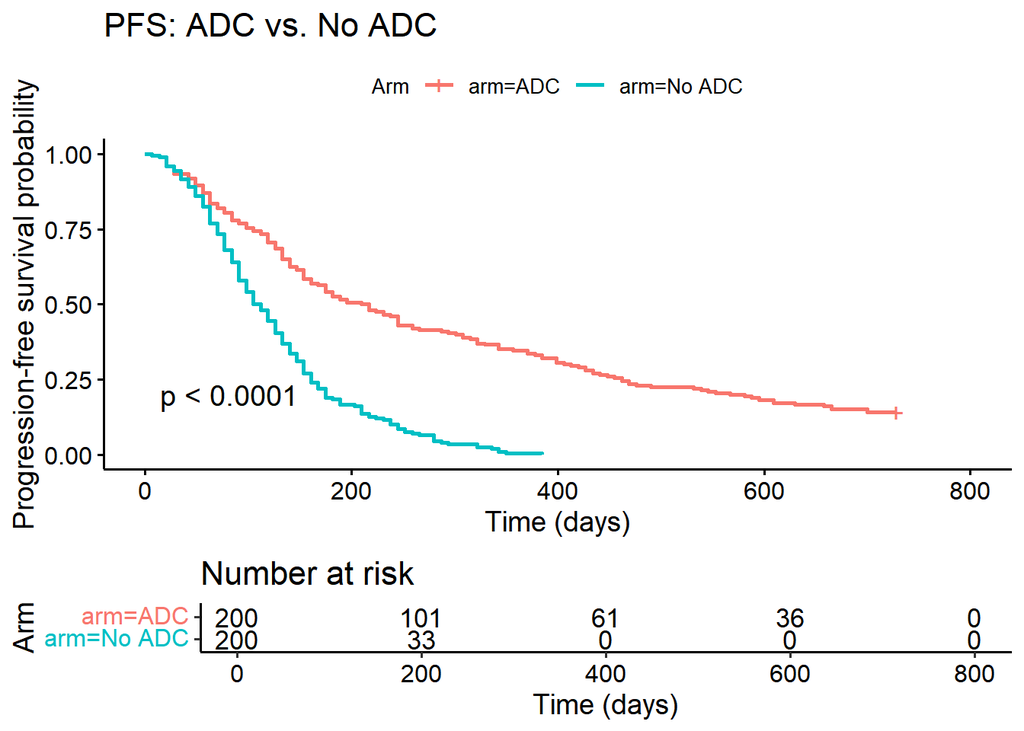

```r
km_pfs <- survfit(Surv(pfs_time, pfs_event) ~ arm, data = pfs_data_combined)

ggsurvplot(km_pfs, data = pfs_data_combined, risk.table = TRUE, pval = TRUE,
           xlab = "Time (days)", ylab = "Progression-free survival probability",
           title = "PFS: ADC vs. No ADC", legend.title = "Arm")
```

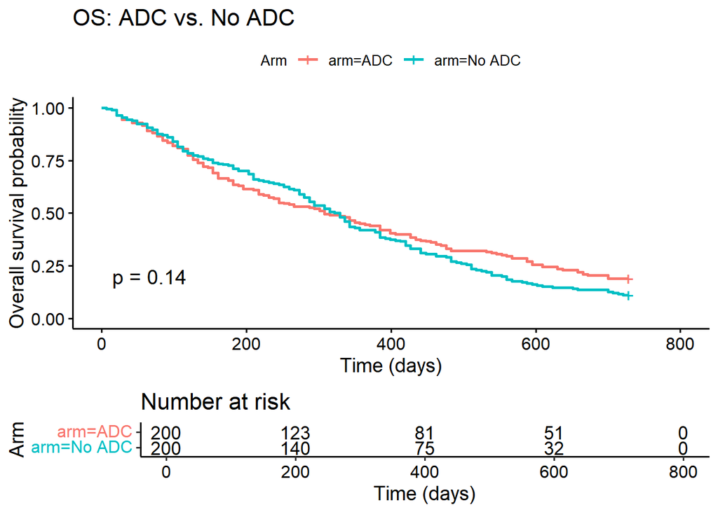

```r
km_os <- survfit(Surv(os_time, os_event) ~ arm, data = pfs_data_combined)

ggsurvplot(km_os, data = pfs_data_combined, risk.table = TRUE, pval = TRUE,
           xlab = "Time (days)", ylab = "Overall survival probability",
           title = "OS: ADC vs. No ADC", legend.title = "Arm")
```

```r
pfs_logrank <- survdiff(Surv(pfs_time, pfs_event) ~ arm, data = pfs_data_combined)
os_logrank <- survdiff(Surv(os_time, os_event) ~ arm, data = pfs_data_combined)
pfs_p_value <- pchisq(pfs_logrank$chisq, df = 1, lower.tail = FALSE)
os_p_value <- pchisq(os_logrank$chisq, df = 1, lower.tail = FALSE)
c(PFS_logrank_p = pfs_p_value, OS_logrank_p = os_p_value)
```

```
## PFS_logrank_p  OS_logrank_p
##  7.502546e-22  1.447924e-01
```

```r
pfs_data_combined %>%
  group_by(arm) %>%
  summarise(median_pfs = median(pfs_time), median_os = median(os_time),
            pfs_event_rate = mean(pfs_event), os_event_rate = mean(os_event))
```

```
## # A tibble: 2 × 5
##   arm    median_pfs median_os pfs_event_rate os_event_rate
##   <chr>       <dbl>     <dbl>          <dbl>         <dbl>
## 1 ADC          214.      308            0.86          0.81
## 2 No ADC       108.      326.           1             0.89
```

```r
pfs_data_combined %>% filter(arm == "ADC") %>% summarise(never_progressed = mean(progression_event == 0))
```

```
## # A tibble: 1 × 1
##   never_progressed
##              <dbl>
## 1             0.53
```

**Result and interpretation.** The table, curves, and computed `PFS_logrank_p` and `OS_logrank_p` above are the authoritative results for this version of the model. Historical p-values are not retained in prose because correcting the integration step, growth parameter, and OS mechanism changes the generated endpoints. Any observed separation describes one seeded simulation and is not clinical evidence for a product.

### Sensitivity of progression to `Emax`

Because `Emax = 0.003` is a scenario calibration, we show how strongly the treated-arm progression rate depends on it. Each value is simulated with 5 independent seeds (same lesion and PK/PD construction as Sections 3-7, treated arm only; OS is not simulated here). It only considers target-lesion progression, without the new-lesion process of Section 8, to isolate the effect of `Emax`. This block runs after all results above and does not affect them.

```r
run_progression_rate <- function(Emax_value, seed) {
  set.seed(seed)
  pts <- patients %>% mutate(kel_i = rlnorm(n(), meanlog = log(0.05), sdlog = 0.20))
  lesion_tbl <- pts %>%
    rowwise() %>%
    do({
      pt <- .
      n <- sample(n_lesions_min:n_lesions_max, 1)
      tibble(patient_id = pt$patient_id, d_daily = pt$d * runif(n, 0.7, 1.3) / 7,
             SLD0_lesion = (pt$SLD0 / n) * runif(n, 0.7, 1.3))
    }) %>%
    ungroup()
  inhib <- lapply(seq_len(nrow(pts)), function(k) {
    emax_effect(repeated_dose_concentration(time_grid, pts$kel_i[k], dosing_times, dose, V),
                Emax_value, EC50)
  })
  names(inhib) <- pts$patient_id
  paths <- lapply(seq_len(nrow(lesion_tbl)), function(k) {
    h <- inhib[[as.character(lesion_tbl$patient_id[k])]]
    x <- numeric(length(time_grid)); x[1] <- lesion_tbl$SLD0_lesion[k]
    for (t in 2:length(time_grid)) {
      x[t] <- x[t - 1] + (time_grid[t] - time_grid[t - 1]) *
        (lesion_tbl$d_daily[k] - h[t - 1]) * x[t - 1]
    }
    data.frame(patient_id = lesion_tbl$patient_id[k], time = time_grid, sld = x)
  })
  total <- bind_rows(paths) %>%
    group_by(patient_id, time) %>%
    summarise(SLD_total = sum(sld), .groups = "drop")
  mean(extract_progression_times(detect_progression(total, "SLD_total"))$progression_event == 1)
}

sens_grid <- expand.grid(Emax = c(0, 0.003, 0.01, 0.05), seed = 101:105)
sens_grid$progression_rate <- mapply(run_progression_rate, sens_grid$Emax, sens_grid$seed)

sens_grid %>%
  group_by(Emax) %>%
  summarise(mean_progression_rate = mean(progression_rate),
            min = min(progression_rate), max = max(progression_rate), .groups = "drop")
```

```
## # A tibble: 4 × 4
##    Emax mean_progression_rate   min   max
##   <dbl>                 <dbl> <dbl> <dbl>
## 1 0                     1      1    1
## 2 0.003                 0.245  0.23 0.255
## 3 0.01                  0.001  0    0.005
## 4 0.05                  0      0    0
```

**Sensitivity reading.** `Emax = 0` is the no-drug reference; larger values quickly suppress progression altogether. The chosen `0.003` sits in the narrow range where the treated arm still progresses in part of the population, which is why it was retained: at larger values the PFS comparison would be degenerate. The result is therefore highly sensitive to this parameter, another reason not to read the contrasts as clinical effects.

## 10. General conclusion, limitations, and next decisions

This notebook connects the two previously separate strands of the project: the multi-lesion RECIST framework (notebook 3) and the ADC PK/PD mechanism (notebook 2), extended here to repeated q3w dosing via the pharmacokinetic superposition principle. The corrected model estimates treatment contrasts for both PFS and OS without using a future tumor measurement to generate earlier deaths. Their magnitude and significance must be read from the executed notebook rather than from previously calibrated, now-obsolete values.

Across the four notebooks, the project now provides one traceable chain from simulated patient heterogeneity to longitudinal tumor dynamics, ADC exposure, lesion-level response, RECIST progression, PFS, and OS. The main conclusion is methodological: the framework connects these quantities coherently, while its calibrated parameters and same-source counterfactuals remain unsuitable for clinical-effect claims.

**Decisions for a future iteration:**

1. Replace empirically calibrated PD and hazard parameters with literature-based or estimated values and document parameter uncertainty.
2. Extend the implemented stop-at-progression rule to model subsequent therapy, dose delays, reductions, and toxicity-driven discontinuations.
3. Link new-lesion appearance to tumor burden and exposure, and add non-target disease to the RECIST implementation.
4. Run repeated simulation scenarios and report uncertainty intervals for treatment effects instead of a single seeded realization.
5. Validate the workflow on an independent clinical dataset before drawing any translational conclusion.

**Limitations, stated explicitly:**

- `Emax = 0.003` is an empirical repeated-dose scenario calibration and intentionally differs from notebook 2’s single-dose value (`0.05`). Repeated q3w exposure made the larger value suppress progression almost completely. Neither value is a literature-derived or fitted ADC estimate.
- Euler updates explicitly multiply daily rates by the seven-day grid interval. A smaller integration grid or validated ODE solver remains preferable for numerical sensitivity analysis.
- OS uses a piecewise-constant, time-varying hazard based on tumor burden known at the beginning of each interval. Tumor burden is a simulated prognostic biomarker here; this association is not evidence that changing tumor size causally changes survival.
- For the OS trajectory, ADC effect stops at the first progression detected on the weekly grid. This avoids attributing continued post-progression benefit to the study treatment. Subsequent therapy, delayed discontinuation, dose modification, and toxicity-driven stopping are still not modeled.
- New lesions appear as a Poisson process with an assumed rate, identical in both arms (no ADC effect on new-lesion development) and unrelated to tumor burden. Non-target disease is not modeled. Because the ADC is assumed not to prevent new lesions, its PFS benefit is diluted relative to a model where treatment also delays them.
- As in notebook 2, all patients follow the same fixed q3w schedule; real-world dose modifications, delays, and discontinuations due to toxicity are not modeled.